# Dev Notebook - 1

```r
library(igraph)
library(tidyverse)
library(ggraph)
library(graphkernels) #for mutag

data(mutag)
```

# Intro

In this notebook I am exploring developing the graph kernel and random walk processes in R, without relying on another’s package. I am doing this because it will give me better command of the material and the `{graph kernels}` package is written in C++ … which I really can’t read at that level.

So for the graph kernel I will need to have a graph and then perform a random walk on the graph before I can compute a kernel. So this is the first target.

# Random Walk

For this project I will be using the `{igraph}` package to let me focus more on the operations on the graphs instead of creating the graphs myself.

I will use the `mutag` dataset for this development. This dataset features *rich* graphs with node and edge attributes. In the future, the node attribute for my thesis will be a word; this will be fine for now. Below is a plot of one of the `mutag` graphs.

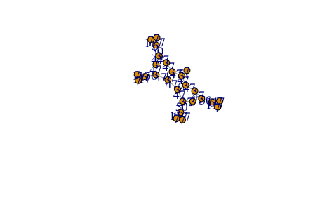

```r
plot(mutag[[2]])
```

To complete a random walk, I will need to pick a node at random, and then randomly pick one of it’s neighbors to visit, and repeat until the length I specify is met. So first let’s pick a node at random!

```r
set.seed(23)

# Get graph from mutag
sample_graph <- mutag[[2]]

# Find out how many nodes there are. May be a better function for this.
num_nodes <- dim(igraph::as_adjacency_matrix(sample_graph))

# Pick a random node.
random_node <- sample(seq(from = 1,
                   to = num_nodes[1]),1)

# Perform random walk.
my_rw <- igraph::random_walk(graph = sample_graph,
                    start = random_node,
                    steps = 1000)
```

Now that we performed a random walk with the help of `{igraph}`, I want to visualize it.

```
Using `stress` as default layout
```

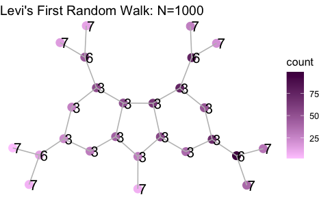

```r
# count how many times a node was visited.
node_counts <- as_tibble(unlist(as.list(my_rw))) %>%
  count(value)

vertex.attributes(sample_graph)$count <- node_counts$n

sample_graph %>%
  ggraph()+
  geom_node_point(aes(color = count), size = 3.5) +
  geom_edge_link(color = "grey") +
  geom_node_text(aes(label = label), color = "black", size = 5, nudge_x = 0.2) +
  scale_color_gradient(low = "#ffccff",
                       high = "#4d004d") +
  theme_void() +
  labs(title = "Levi's First Random Walk: N=1000")
```

```r
NA
NA
NA
```

# Other section (???)

In the slides from *Vishwanathan*, available [here](https://github.com/Levi-Nicklas/GraphKernels/blob/master/RelevantPapers_and_Resources/vish_presentation.pdf), he outlines the steps to compute a random walk graph kernel using prinicples from linear algebra. Let’s dive in. I’ll build a small section on each important mathematical concept in the slides.

## Probability of Next Step

*Vishwanathan* shows in the slides that we can use the adjacency matrix, $A$, to find the probability of going from one node to another in $n$ step length random walk. For examle, in the example above (`mutag[2]`), we can find the probability of going from node 10 to node 13 like so:

```r
#Get the adjacency matrix.
mutag2_adj_mat <- igraph::as_adjacency_matrix(sample_graph) %>%
  as.matrix()

#Build matrix exponentiation.
exp_mat <- function(your_matrix, n){
  tmp <- your_matrix

  for(i in 1:(n-1)){
   tmp <- tmp %*% your_matrix
  }

  return(tmp)
}

#Check...
#exp_mat(mutag2_adj_mat,4) == (mutag2_adj_mat %*% mutag2_adj_mat %*% mutag2_adj_mat %*% mutag2_adj_mat)

#Calculate random walks of length 7.
exp_mat(mutag2_adj_mat, 7)
```

```
      [,1] [,2] [,3] [,4] [,5] [,6] [,7] [,8] [,9] [,10] [,11] [,12] [,13] [,14] [,15] [,16] [,17] [,18] [,19]
 [1,]    2  108    1   99   13  121   14   35   54    67    13    13    12    13     2     1     1    13     1
 [2,]  108    0  108    1  110    3   65    2   24    13    24     2     4    12     1     0     0     1     2
 [3,]    1  108    0  119    3   99   13   19   23    67     2    13     2    13     2     0     0    13     0
 [4,]   99    1  119    2  175   14   76   11   69    15    69     2    24    13     1     2     2     1    11
 [5,]   13  110    3  175   26  177   68   45   67   181    15    67    13    67    24     1     1    65     1
 [6,]  121    3   99   14  177   26  145   12   70    67    69    23    24    54    13     2     2    14    11
 [7,]   14   65   13   76   68  145   26   65  145    68    76    13    65    14     2    11    11    13    12
 [8,]   35    2   19   11   45   12   65    2   12    45    11    19     2    35    11     0     0    12     1
 [9,]   54   24   23   69   67   70  145   12   26   177    14    99     3   121    63     0     0    74     1
[10,]   67   13   67   15  181   67   68   45  177    26   175     3   110    13     1    20    20     2    43
[11,]   13   24    2   69   15   69   76   11   14   175     2   119     1    99    63     0     0   122     0
[12,]   13    2   13    2   67   23   13   19   99     3   119     0   108     1     0    32    32     0    33
[13,]   12    4    2   24   13   24   65    2    3   110     1   108     0   108   109     0     0    63     0
[14,]   13   12   13   13   67   54   14   35  121    13    99     1   108     2     0    32    32     1    19
```

[output cut: 39 more lines]

Now that we computed $A^n$, we need to compute $\tilde{A}^n$, which is the probability of walks length $n$. This is done by $\tilde{A} = A D^{-1}$, where $D$ is the diagonal matrix of node degrees.

```r
mutag2_deg_mat<- igraph::degree(sample_graph) %>%
  diag()

# Check that solve() does what I think it does lol.
# mutag2_deg_mat %*% solve(mutag2_deg_mat)
# returns identity matrix... all good here :)

# Normalize Adj matrix by degree matrix.
mutag2_adjnorm_mat <- mutag2_adj_mat %*% solve(mutag2_deg_mat)
```

Great! Now when we compute $\tilde{A}^{n}$ we are computing the probability of a walk from $i$ to $j$ (the entry in the matrix, that is).

```r
# Check that probability sums to 1.
# exp_mat(mutag2_adjnorm_mat, 7) %>%
#  as.data.frame() %>%
#  summarise_all(.funs = sum)

# Check probabilty of taking a walk of length 7
# from node 10 to node 15.
exp_mat(mutag2_adjnorm_mat, 7)[15,17]
```

```
[1] 0.5466392
```

```r
# Check probabilty of taking a walk of length 7
# from node 10 to node 20.
exp_mat(mutag2_adjnorm_mat, 7)[15,20]
```

```
[1] 0.04218107
```

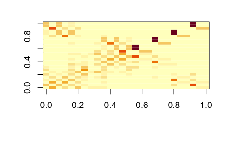

```r
exp_mat(mutag2_adjnorm_mat, 7) %>%
  image()
```

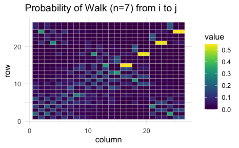

```r
# make a test df to try visualizations.
test_df <- exp_mat(mutag2_adjnorm_mat, 7) %>%
  as.data.frame()

# store the row names.
test_df$row <- rownames(test_df)

# change colnames to integers
colnames(test_df) <- c(1:26, "row")

# pivot_longer()
test_df_long<- test_df %>%
  pivot_longer(cols = (1:26)) %>%
  mutate(row = as.numeric(row),
         column = as.numeric(name)) %>%
  select(row, column, value)

test_df_long %>%
  ggplot(aes(x = column, y = row, fill = value)) +
  geom_tile(color = "white") +
  scale_fill_viridis() +
  theme_minimal()+
  labs(x = "column", y = "row",
       title = "Probability of Walk (n=7) from i to j")
```

```r
# ^^ Clean this up with more frequent labels on axis
# remove excess gridlines
# change scale from [0,1]
```

```r
# Not like this...Im pretty sure.
t(spectrum(sample_graph)$vectors / (factorial(7))) %*%  exp_mat(mutag2_adjnorm_mat, 7) %>%
  sum()
```

```
[1] 0.001000851
```

```r
data(mutag)
K <- CalculateVertexHistKernel(mutag[1:7])

K
```

```
     [,1] [,2] [,3] [,4] [,5] [,6] [,7]
[1,]  405  282  325  405  247  327  335
[2,]  282  266  230  282  186  239  274
[3,]  325  230  261  325  199  263  271
[4,]  405  282  325  405  247  327  335
[5,]  247  186  199  247  157  201  213
[6,]  327  239  263  327  201  266  277
[7,]  335  274  271  335  213  277  301
```